# Reproducible Research Project 1

## Introduction

This is an R Markdown document for Reproducible Research’s project 1. This project analyses data about personal activity activity monitoring devices such as a [Fitbit](http://www.fitbit.com/#i.yzjwip6xjejstg), [Nike Fuelband](http://www.nike.com/us/en_us/c/nikeplus-fuel), or [Jawbone Up](https://jawbone.com/up). These type of devices are part of the “quantified self” movement - a group of enthusiasts who take measurements about themselves regularly to improve their health, to find patterns in their behavior, or because they are tech geeks. But these data remain under-utilized both because the raw data are hard to obtain and there is a lack of statistical methods and software for processing and interpreting the data.

## Data

The data for this assignment can be downloaded from the course web site:

```
Dataset: Activity monitoring data [52K]
```

The variables included in this dataset are:

```
steps: Number of steps taking in a 5-minute interval (missing values are coded as NA)

date: The date on which the measurement was taken in YYYY-MM-DD format

interval: Identifier for the 5-minute interval in which measurement was taken
```

The dataset is stored in a comma-separated-value (CSV) file and there are a total of 17,568 observations in this dataset.

## Load libraries

```r
library(dplyr)
library(lubridate)
library(lattice)
```

## Loading and preprocessing the data

```r
if(!file.exists("activity.csv")) {
    download.file(url = "http://d396qusza40orc.cloudfront.net/repdata%2Fdata%2Factivity.zip", destfile = "repdata_data_activity.zip", mode ="wb")
    unzip("repdata_data_activity.zip")
}

activityData <- read.csv("activity.csv", colClasses = c("integer", "Date", "integer"))
activity_df <- tbl_df(activityData)
```

## Question 1. What is mean total number of steps taken per day?

Group by same date, then sum steps.

```r
totalStepsPerDay <- activity_df %>%  # dplyr package is needed
    group_by(date) %>%
    summarise(steps = sum(steps, na.rm = TRUE))
```

Plot data:

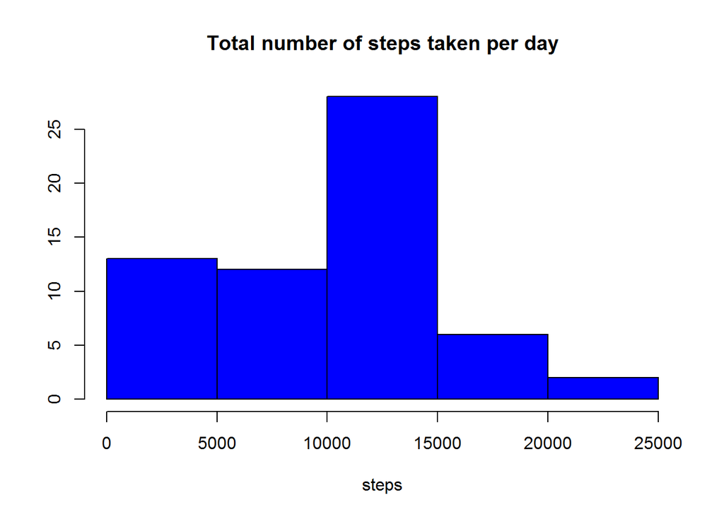

```r
with(totalStepsPerDay, hist(steps, main = "Total number of steps taken per day",
                            xlab = "steps", ylab = "", col = "blue1"))
```

Look at mean and median from number of step taken per day.

```r
meanMedianData <- activityData %>%  # dplyr package is needed
    group_by(date) %>%
    summarise(meanStep = mean(steps, na.rm = TRUE), medianStep = median(steps, na.rm = TRUE))
meanMedianData
```

```
## Source: local data frame [61 x 3]
##
##          date meanStep medianStep
## 1  2012-10-01      NaN         NA
## 2  2012-10-02  0.43750          0
## 3  2012-10-03 39.41667          0
## 4  2012-10-04 42.06944          0
## 5  2012-10-05 46.15972          0
## 6  2012-10-06 53.54167          0
## 7  2012-10-07 38.24653          0
## 8  2012-10-08      NaN         NA
## 9  2012-10-09 44.48264          0
## 10 2012-10-10 34.37500          0
## ..        ...      ...        ...
```

## Question 2. What is the average daily activity pattern?

Group by interval, then we average steps

```r
avgStepsAcrossDay <- activity_df %>%  # dplyr package is needed
    group_by(interval) %>%
    summarise(avgSteps = mean(steps, na.rm = TRUE))
```

Then we create a line plot.

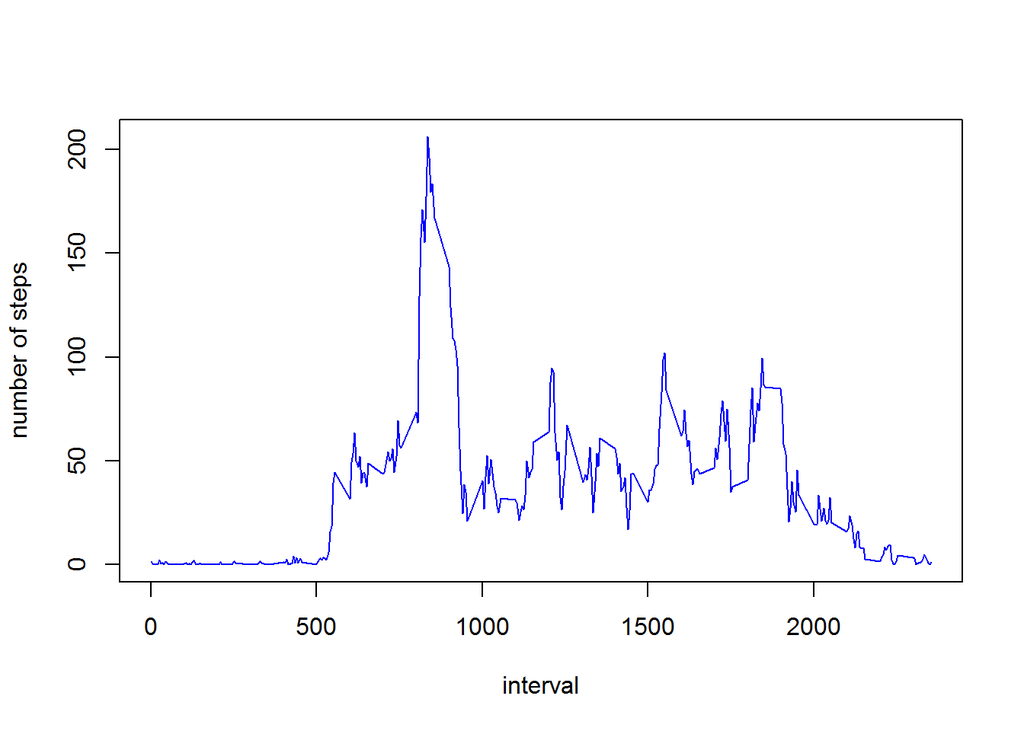

```r
with(avgStepsAcrossDay, plot(x = interval, y = avgSteps,
                             ylab = "number of steps",
                             type = "l", col = "blue1"))
```

5-minute interval, on average across all the days in the dataset, contains the maximum number of steps:

```r
# Sort desc average number of steps
avgStepsAcrossDay <- arrange(avgStepsAcrossDay, desc(avgSteps))
avgStepsAcrossDay[1,1]
```

```
## Source: local data frame [1 x 1]
##
##   interval
## 1      835
```

## Question 3. Inputing missing values

To fill missing value of analytic data. We get a dataset for averaging number of steps based on interval (*we had from Question 2*). We get all missing value of analytic data. After that, we loop this data, update number of steps whose value is get from averaging data that interval of them is same.

Please see code below:

```r
# Create new data
newActivityData <- activityData
indexMissingData <- which(is.na(activityData$steps))

for(i in indexMissingData) {
    newActivityData$steps[i] <- with(avgStepsAcrossDay, round(avgSteps[interval == newActivityData$interval[i]]))
}
```

Then , to plot total number of steps for new data filled. We do same things question 1.

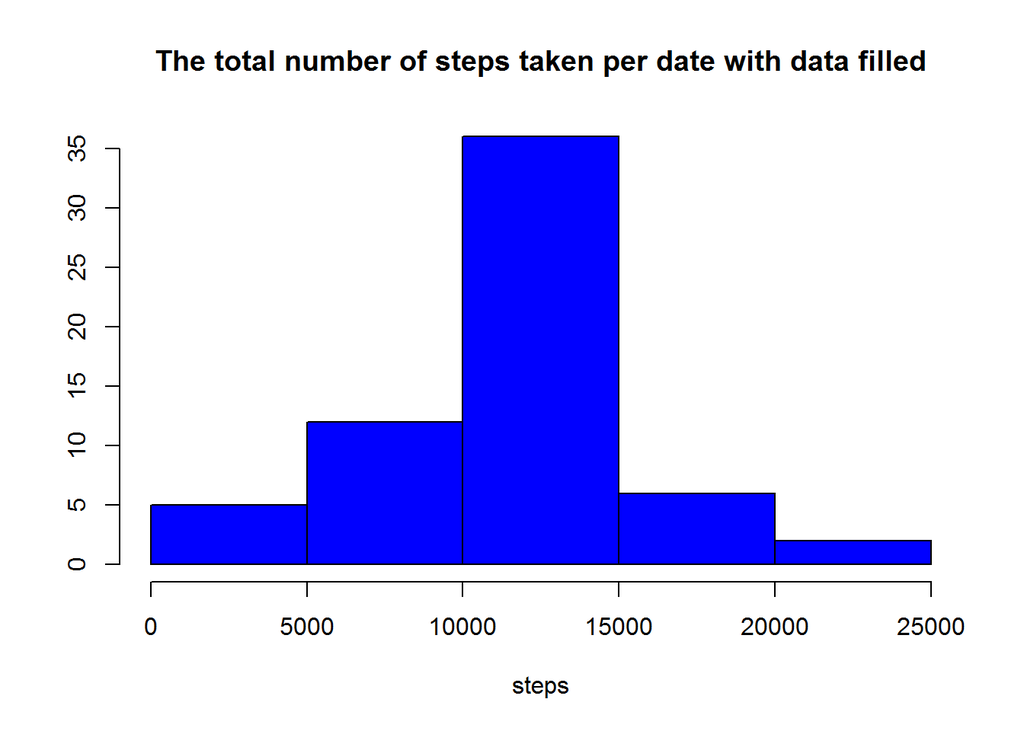

```r
totalStepsPerDayNew <- newActivityData %>%  # dplyr package is needed
    group_by(date) %>%
    summarise(steps = sum(steps, na.rm = TRUE))

with(totalStepsPerDayNew, hist(steps, main = "The total number of steps taken per date with data filled", xlab = "steps", ylab = "", col = "blue1"))
```

Look at mean and median from number of step taken per day for new data filled missing value.

```r
meanMedianDataNew <- newActivityData %>%  # dplyr package is needed
    group_by(date) %>%
    summarise(meanStep = mean(steps, na.rm = TRUE), medianStep = median(steps, na.rm = TRUE))
meanMedianDataNew
```

```
## Source: local data frame [61 x 3]
##
##          date meanStep medianStep
## 1  2012-10-01 37.36806       34.5
## 2  2012-10-02  0.43750        0.0
## 3  2012-10-03 39.41667        0.0
## 4  2012-10-04 42.06944        0.0
## 5  2012-10-05 46.15972        0.0
## 6  2012-10-06 53.54167        0.0
## 7  2012-10-07 38.24653        0.0
## 8  2012-10-08 37.36806       34.5
## 9  2012-10-09 44.48264        0.0
## 10 2012-10-10 34.37500        0.0
## ..        ...      ...        ...
```

## Question4. Are there differences in activity patterns between weekdays and weekends?

We will add extra column - typeDate (weekday or weekend).

```r
newActivityData <- mutate(newActivityData, typeDate = ifelse(wday(date) == 1 | wday(date) == 7, "weekend", "weekday"))
newActivityData$typeDate <- as.factor(newActivityData$typeDate)
```

We group dataset by typeDate, interval, then sum number of steps.

```r
newActivityDataTotal <- newActivityData %>% group_by(typeDate, interval) %>% summarise(steps = sum(steps))
```

Finally, We plot data to analyse number of steps by interval for each of type date.

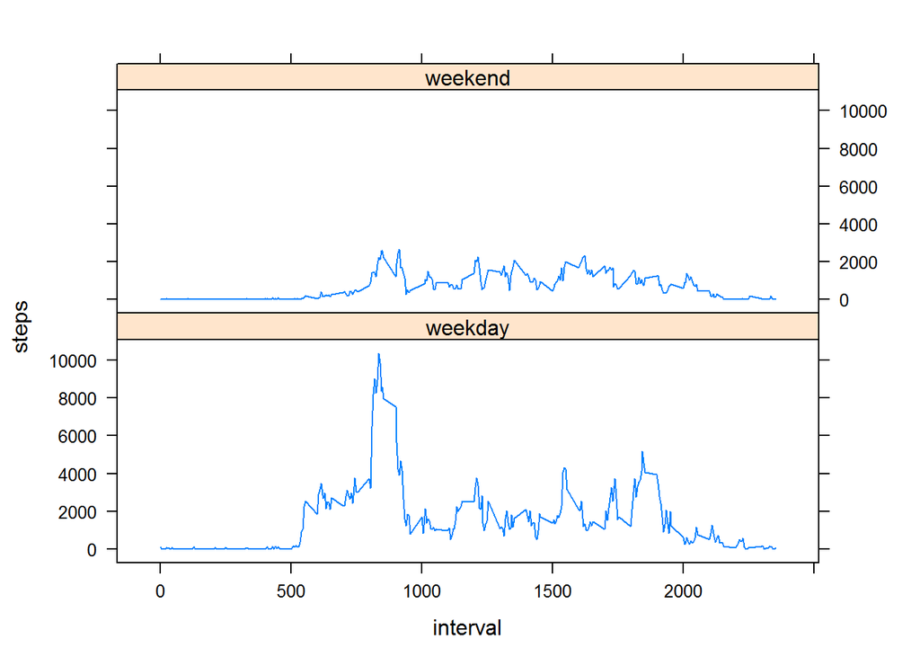

```r
with(newActivityDataTotal, xyplot(steps ~ interval | typeDate, type = "l", layout = c(1, 2)))
```